# Exam 2 review activity

# Overview

In this activity, you will work with data from the 1977-1978 Australian Health Survey. The `DoctorVisits` data contains information on 5190 respondents, and the researchers analyzing the data are interested in the number of times each respondent visited the doctor in the past 2 weeks. The variables include:

- `visits`: Number of doctor visits in past 2 weeks.
- `gender`: Factor indicating gender.
- `age`: Age in years divided by 100.
- `income`: Annual income in tens of thousands of dollars.
- `insurance`: type of health insurance. Possible types are None, Private, Free (poor), and Free (repat). Free (poor) indicates free health insurance due to low income, while Free (repat) indicates free health insurance due to old age, disability, or veteran status.

## Questions

### Initial Poisson model

The researchers are interested in modeling the number of doctor visits in the past 2 weeks. Since the number of doctor visits is a count variable, they propose using a Poisson regression model. Below is the output of their fitted model:

```
##
## Call:
## glm(formula = visits ~ gender + age + income + insurance, family = poisson,
##     data = DoctorVisits)
##
## Deviance Residuals:
##     Min       1Q   Median       3Q      Max
## -1.0536  -0.7891  -0.6730  -0.5878   6.3097
##
## Coefficients:
##                    Estimate Std. Error z value Pr(>|z|)
## (Intercept)        -1.66099    0.09724 -17.081  < 2e-16 ***
## genderfemale        0.18533    0.05664   3.272 0.001068 **
## age                 0.90922    0.16166   5.624 1.86e-08 ***
## income             -0.29751    0.08606  -3.457 0.000546 ***
## insuranceprivate    0.14918    0.07088   2.105 0.035319 *
## insurancefreepoor  -0.40545    0.17989  -2.254 0.024205 *
## insurancefreerepat  0.25013    0.09264   2.700 0.006931 **
## ---
## Signif. codes:  0 '***' 0.001 '**' 0.01 '*' 0.05 '.' 0.1 ' ' 1
##
## (Dispersion parameter for poisson family taken to be 1)
##
##     Null deviance: 5634.8  on 5189  degrees of freedom
## Residual deviance: 5417.7  on 5183  degrees of freedom
## AIC: 7763.3
##
## Number of Fisher Scoring iterations: 6
```

1. Write down the population Poisson model corresponding to the fitted model shown in the R output above.
2. Interpret the estimated slope $\widehat{\beta}_2$ in terms of the number of doctor visits in the past 2 weeks.
3. An offset was not used in this model. Describe a situation in which we might want to use an offset when modeling the number of doctor visits.
4. After accounting for the other variables in the model, is there a relationship between income and the number of doctor visits in the past 2 weeks? Use a hypothesis test to answer this question; you should be able to calculate your test statistic from the output above.
5. What is the estimated number of doctor visits in the past 2 weeks for a male participant, aged 20, with no health insurance, who makes $5000 annually?

### Model diagnostics

The Poisson model assumes that the Poisson distribution is a good choice for the response. What if it isn’t? To choose between a Poisson, quasi-Poisson, and negative binomial model, the researchers produce the following output in R:

```
##
## Call:
## glm(formula = visits ~ gender + age + income + insurance, family = quasipoisson,
##     data = DoctorVisits)
##
## Deviance Residuals:
##     Min       1Q   Median       3Q      Max
## -1.0536  -0.7891  -0.6730  -0.5878   6.3097
##
## Coefficients:
##                    Estimate Std. Error t value Pr(>|t|)
## (Intercept)        -1.66099    0.13948 -11.908  < 2e-16 ***
## genderfemale        0.18533    0.08124   2.281   0.0226 *
## age                 0.90922    0.23188   3.921 8.93e-05 ***
## income             -0.29751    0.12344  -2.410   0.0160 *
## insuranceprivate    0.14918    0.10167   1.467   0.1423
## insurancefreepoor  -0.40545    0.25803  -1.571   0.1162
## insurancefreerepat  0.25013    0.13287   1.882   0.0598 .
## ---
## Signif. codes:  0 '***' 0.001 '**' 0.01 '*' 0.05 '.' 0.1 ' ' 1
##
## (Dispersion parameter for quasipoisson family taken to be 2.057397)
##
##     Null deviance: 5634.8  on 5189  degrees of freedom
## Residual deviance: 5417.7  on 5183  degrees of freedom
## AIC: NA
##
## Number of Fisher Scoring iterations: 6
```

```
##
## Call:
## glm.nb(formula = visits ~ gender + age + income + insurance,
##     data = DoctorVisits, init.theta = 0.4319080953, link = log)
##
## Deviance Residuals:
##     Min       1Q   Median       3Q      Max
## -0.8498  -0.6869  -0.6015  -0.5382   3.9876
##
## Coefficients:
##                    Estimate Std. Error z value Pr(>|z|)
## (Intercept)        -1.68994    0.12316 -13.721  < 2e-16 ***
## genderfemale        0.21565    0.07370   2.926  0.00343 **
## age                 0.92155    0.21373   4.312 1.62e-05 ***
## income             -0.28058    0.10965  -2.559  0.01050 *
## insuranceprivate    0.13873    0.08902   1.558  0.11914
## insurancefreepoor  -0.40597    0.21293  -1.907  0.05658 .
## insurancefreerepat  0.25590    0.12315   2.078  0.03771 *
## ---
## Signif. codes:  0 '***' 0.001 '**' 0.01 '*' 0.05 '.' 0.1 ' ' 1
##
## (Dispersion parameter for Negative Binomial(0.4319) family taken to be 1)
##
##     Null deviance: 3119.9  on 5189  degrees of freedom
## Residual deviance: 2990.4  on 5183  degrees of freedom
## AIC: 7062
##
## Number of Fisher Scoring iterations: 1
##
##
##               Theta:  0.4319
##           Std. Err.:  0.0316
##
##  2 x log-likelihood:  -7046.0330
```

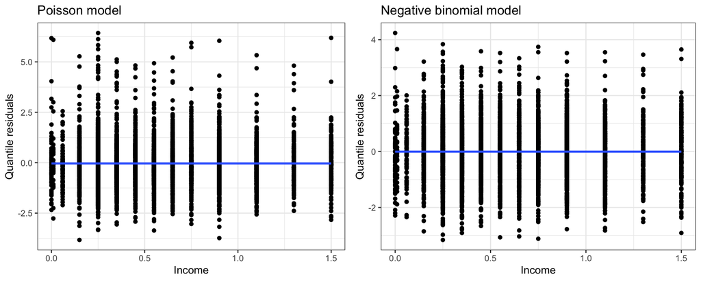

### ZIP models

Concerned about the possibility of zero-inflation, the researchers decide to fit a ZIP model instead:

```
##
## Call:
## zeroinfl(formula = visits ~ gender + age + income + insurance, data = DoctorVisits)
##
## Pearson residuals:
##     Min      1Q  Median      3Q     Max
## -0.6322 -0.4544 -0.3766 -0.3197 12.4987
##
## Count model coefficients (poisson with log link):
##                    Estimate Std. Error z value Pr(>|z|)
## (Intercept)         0.11676    0.16135   0.724  0.46928
## genderfemale       -0.13686    0.08887  -1.540  0.12355
## age                 0.36657    0.25216   1.454  0.14603
## income             -0.40862    0.14448  -2.828  0.00468 **
## insuranceprivate   -0.12401    0.11844  -1.047  0.29507
## insurancefreepoor   0.18349    0.26248   0.699  0.48451
## insurancefreerepat -0.32347    0.14177  -2.282  0.02251 *
##
## Zero-inflation model coefficients (binomial with logit link):
##                    Estimate Std. Error z value Pr(>|z|)
## (Intercept)          1.7045     0.2165   7.875 3.41e-15 ***
## genderfemale        -0.5208     0.1304  -3.994 6.49e-05 ***
## age                 -0.7968     0.3704  -2.151   0.0315 *
## income              -0.1971     0.2010  -0.981   0.3267
## insuranceprivate    -0.3882     0.1556  -2.494   0.0126 *
## insurancefreepoor    0.7017     0.3103   2.261   0.0238 *
## insurancefreerepat  -1.0136     0.2232  -4.541 5.59e-06 ***
## ---
## Signif. codes:  0 '***' 0.001 '**' 0.01 '*' 0.05 '.' 0.1 ' ' 1
##
## Number of iterations in BFGS optimization: 20
## Log-likelihood: -3614 on 14 Df
```

10. What is a potential latent variable which could cause excess 0s in this data?
11. Write down the population ZIP model corresponding to the fitted ZIP model above. Make sure to include the random component!
12. What is the estimated number of doctor visits in the past 2 weeks for a male participant, aged 20, with no health insurance, who makes $5000 annually?
13. What is the estimated probability that a male participant, aged 20, with no health insurance, who makes $5000 annually, did not go to the doctor in the past 2 weeks?
14. What does the logistic component of the ZIP model estimate? (i.e., the component that R calls the `zero-inflation model`, in contrast to the `count model`).